# 13. Test9 original-paper figure reanalysis

2026-09-30

# 1 Scope and interpretation

This is a cross-sectional, repeated-body-site reanalysis of the original BP study. The approved input is script 12’s **pooled prevalence decontam, threshold 0.5**: skin swabs versus negative extraction controls. Its fitting population is retained before restricting to the published biological samples. Scripts 09–12 are not modified.

Alpha and beta diversity use 5,000-read rarefaction **after** contaminant removal and biological-sample merging. Taxonomic composition and BPDAI correlations use unrarefied decontaminated counts converted to within-sample relative abundance. No additional abundance filter or batch-correction algorithm is introduced.

Perilesional means skin within 2 cm of a fresh BP lesion; contralateral means unaffected skin on the opposite side of the same patient’s body at the corresponding anatomical location. Corresponding samples are anatomically matched control skin. Site suffixes 1/2 are retained in metadata. These are sampling locations, not longitudinal visits. The contralateral samples are patient samples, not healthy controls.

The independent DADA2 features and current taxonomy differ from the original analysis. Plots reproduce comparison structure, not original ASV identifiers or published numerical results. The original Fig. 2 used partial constrained ordination; the PCoA panels here are explicitly **unconstrained descriptive PCoA**.

Source: [Belheouane et al., J Adv Res](https://doi.org/10.1016/j.jare.2022.03.019).

# 2 Official clinical tables and matching

```r
supp_file <- file.path(project_dir, "Input/Test9/supplementary_mmc2.xlsx")
supp_url <- "https://ars.els-cdn.com/content/image/1-s2.0-S2090123222000819-mmc2.xlsx"
if (!file.exists(supp_file)) download.file(supp_url, supp_file, mode = "wb")
s1 <- readxl::read_excel(supp_file, sheet = "Table_S1 Metadata", skip = 1) |>
  dplyr::filter(Status %in% c("Control", "Patient"), !is.na(Sample_ID))
s5 <- readxl::read_excel(supp_file, sheet = "Table_S5 disease scores", skip = 1) |>
  dplyr::filter(grepl("^BP_", .data[["Sample ID"]])) |>
  dplyr::transmute(individual = .data[["Sample ID"]], BPDAI_date = Date,
                   BPDAI = .data[["Active sum"]], BPDAI_overall = .data[["Overall sum"]],
                   BPDAI_center = .data[["Sampling center (site abbreviation*)"]])
if (anyDuplicated(s1$Sample_ID) || anyDuplicated(s5$individual)) {
  stop("Official clinical keys are duplicated; resolve sample/visit identity before matching.")
}
write_table(data.frame(source = supp_url, file = basename(supp_file),
                       md5 = unname(tools::md5sum(supp_file))), "supplement_source")
knitr::kable(data.frame(table = c("S1 biological samples", "S1 individuals", "S5 BPDAI records"),
                       n = c(nrow(s1), length(unique(s1$Individual)), nrow(s5))))
```

| table | n |
| --- | --- |
| S1 biological samples | 2319 |
| S1 individuals | 418 |
| S5 BPDAI records | 210 |

S5’s **Active sum** is the published disease-activity value. Overall sum is retained for traceability but is not used as the activity endpoint. Clinical missing values are not imputed. BPDAI is attached by exact official individual ID; a missing BPDAI excludes a patient only from the BPDAI analysis.

# 3 Reproduce script 12 at threshold 0.5

```r
ps <- readRDS(file.path(project_dir,
  "Results/Test9/09_Test9_preprocessing/260929_Test9_phyloseq_filt.rds"))
meta <- data.frame(sample_data(ps), check.names = FALSE)
meta$sample_id <- rownames(meta)
ps_decontam <- prune_samples(meta$sample_id[meta$sample_type %in%
  c("Skin swab", "Negative Extraction Control")], ps)
ps_decontam <- prune_taxa(taxa_sums(ps_decontam) > 0, ps_decontam)
sample_data(ps_decontam)$decontam_group <- ifelse(
  sample_data(ps_decontam)$sample_type == "Negative Extraction Control",
  "Negative Extraction Control", "Skin swab")
scores <- decontam::isContaminant(ps_decontam, method = "prevalence",
  neg = sample_data(ps_decontam)$decontam_group == "Negative Extraction Control",
  normalize = TRUE, detailed = TRUE)
scores$prevalence_score <- if ("p" %in% names(scores)) scores$p else scores$p.prev
pkgload::load_all("D:/KSY/Project/기타/decontamSensitivity", quiet = TRUE, export_all = FALSE)
prevalence_result <- decontamSensitivity::run_threshold_sweep(
  decontam_result = scores, count_table = get_counts(ps_decontam),
  metadata = data.frame(sample_data(ps_decontam)), control_column = "decontam_group",
  control_label = "Negative Extraction Control", thresholds = threshold,
  taxonomy = data.frame(tax_table(ps_decontam)), score_column = "prevalence_score",
  features_are_rows = TRUE)
flags <- prevalence_result$feature_flags
direct <- decontam::isContaminant(ps_decontam, method = "prevalence", threshold = threshold,
  neg = sample_data(ps_decontam)$decontam_group == "Negative Extraction Control",
  normalize = TRUE, detailed = TRUE)
if (any(flags$contaminant != direct[flags$feature_id, "contaminant"])) {
  stop("Threshold-sweep flags differ from the direct decontam call.")
}
tax <- data.frame(tax_table(ps_decontam), check.names = FALSE)
tax$feature_id <- rownames(tax)
write_table(dplyr::left_join(flags, tax, by = "feature_id"), "decontam_flags_0.5")
knitr::kable(prevalence_result$threshold_summary)
```

| threshold | contaminant_features | retained_features | retained_samples | zero_read_samples | biological_reads_retained_pct | control_reads_retained_pct | overall_reads_retained_pct | biological_features_retained_pct | control_features_retained_pct | overall_features_retained_pct |
| --- | --- | --- | --- | --- | --- | --- | --- | --- | --- | --- |
| 0.5 | 478 | 79210 | 2799 | 3 | 96.91956 | 64.42543 | 96.83549 | 99.3991 | 46.23172 | 99.40016 |

```r
ps_clean <- prune_taxa(setdiff(taxa_names(ps_decontam), flags$feature_id[flags$contaminant]), ps_decontam)
rm(ps, scores, direct, prevalence_result); gc()
```

```
##             used   (Mb) gc trigger    (Mb)   max used    (Mb)
## Ncells   5220827  278.9    8117300   433.6    8117300   433.6
## Vcells 459123932 3502.9 1886110596 14389.9 2357637473 17987.4
```

The threshold-0.5 flags above are checked against a direct `decontam::isContaminant` call. Mock and negative sampling controls do not enter this fit, matching script 12.

# 4 Published sample intersection and sequencing-run aggregation

```r
meta$official_match <- meta$sample_type == "Skin swab" &
  tolower(as.character(meta$official_s1_sample)) == "true" &
  meta$clinical_source_sample_id %in% s1$Sample_ID
meta$official_match[is.na(meta$official_match)] <- FALSE
meta$reads_before <- sample_sums(ps_decontam)[meta$sample_id]
meta$reads_after <- sample_sums(ps_clean)[meta$sample_id]
meta$inclusion_reason <- ifelse(meta$official_match, "Matched to official S1",
  ifelse(meta$sample_type != "Skin swab", "Not a skin swab", "Not in official S1"))
write_table(meta, "run_matching_and_read_retention")
matched <- meta[meta$official_match, ]
run_groups <- matched |>
  dplyr::group_by(clinical_source_sample_id) |>
  dplyr::summarise(n_runs = dplyr::n(), SRA_runs = paste(sra_run, collapse = ";"),
    submitted_ids = paste(supplementary_sample_id, collapse = ";"),
    match_methods = paste(unique(clinical_match_method), collapse = ";"),
    reads_before = sum(reads_before), reads_after = sum(reads_after), .groups = "drop")
write_table(run_groups, "biological_sample_run_mapping")
write_table(dplyr::anti_join(s1, run_groups, by = c("Sample_ID" = "clinical_source_sample_id")),
            "published_samples_without_current_data")
ps_clean <- prune_samples(matched$sample_id, ps_clean)
matched <- matched[match(sample_names(ps_clean), matched$sample_id), ]
# Sum counts only for runs already mapped to the same original S1 biological sample.
merged_counts <- t(rowsum(t(get_counts(ps_clean)), matched$clinical_source_sample_id, reorder = FALSE))
bio_meta <- data.frame(s1[match(colnames(merged_counts), s1$Sample_ID), ], check.names = FALSE)
bio_meta$individual <- bio_meta$Individual
bio_meta$status <- factor(bio_meta$Status, levels = c("Control", "Patient"))
bio_meta$site <- bio_meta$Site
bio_meta$center <- bio_meta[["Sampling Center"]]
bio_meta$sex <- bio_meta$Sex
bio_meta$extraction_batch <- sub(
  "^extraction", "Extraction",
  sub("_.*$", "", bio_meta$Extraction_plate),
  ignore.case = TRUE
)
bio_meta$sequencing_run <- bio_meta$Run
bio_meta$region <- dplyr::case_when(
  grepl("antecubital", bio_meta$site, ignore.case = TRUE) ~ "Antecubital Fossa",
  bio_meta$site == "Upper Back" ~ "Upper Back", bio_meta$site == "Forehead" ~ "Forehead",
  grepl("^Corresponding", bio_meta$site) ~ "Corresponding",
  grepl("^Perilesional", bio_meta$site, ignore.case = TRUE) ~ "Perilesional",
  grepl("^contralateral", bio_meta$site, ignore.case = TRUE) ~ "Contralateral")
bio_meta$pair_number <- ifelse(grepl("[12]$", bio_meta$site), sub(".*([12])$", "\\1", bio_meta$site), NA)
bio_meta$panel <- ifelse(bio_meta$region %in% c("Antecubital Fossa", "Upper Back", "Forehead"),
                        "Standard sites", "Lesion-related sites")
bio_meta <- dplyr::left_join(bio_meta, s5, by = "individual")
rownames(bio_meta) <- bio_meta$Sample_ID
ps_bio <- phyloseq(otu_table(merged_counts, taxa_are_rows = TRUE),
                  tax_table(ps_clean), sample_data(bio_meta))
ps_bio <- prune_samples(sample_sums(ps_bio) > 0, ps_bio)
ps_bio <- prune_taxa(taxa_sums(ps_bio) > 0, ps_bio)
write_table(bio_meta, "clinical_metadata_with_BPDAI")
matching_summary <- data.frame(stage = c("Current official-matched SRA runs", "Original biological samples",
  "Positive-depth biological samples", "Independent individuals", "Flagged ASVs"),
  n = c(nrow(matched), nrow(bio_meta), nsamples(ps_bio), length(unique(bio_meta$individual)), sum(flags$contaminant)))
write_table(matching_summary, "matching_summary")
knitr::kable(matching_summary)
```

| stage | n |
| --- | --- |
| Current official-matched SRA runs | 2461 |
| Original biological samples | 2319 |
| Positive-depth biological samples | 2319 |
| Independent individuals | 418 |
| Flagged ASVs | 478 |

```r
knitr::kable(bio_meta |> dplyr::group_by(status, region) |>
  dplyr::summarise(samples = dplyr::n(), individuals = dplyr::n_distinct(individual), .groups = "drop"))
```

| status | region | samples | individuals |
| --- | --- | --- | --- |
| Control | Antecubital Fossa | 175 | 175 |
| Control | Corresponding | 334 | 181 |
| Control | Forehead | 184 | 184 |
| Control | Upper Back | 175 | 175 |
| Patient | Antecubital Fossa | 207 | 207 |
| Patient | Contralateral | 407 | 219 |
| Patient | Forehead | 214 | 213 |
| Patient | Perilesional | 415 | 220 |
| Patient | Upper Back | 208 | 208 |

```r
bp_match <- bio_meta |> dplyr::filter(status == "Patient") |>
  dplyr::distinct(individual, BPDAI, BPDAI_date, center, BPDAI_center)
write_table(bp_match, "BPDAI_patient_matching")
knitr::kable(data.frame(BPDAI_match = c("Matched", "Missing"),
                       patients = c(sum(!is.na(bp_match$BPDAI)), sum(is.na(bp_match$BPDAI)))))
```

| BPDAI_match | patients |
| --- | --- |
| Matched | 210 |
| Missing | 18 |

```r
rm(merged_counts, ps_clean, ps_decontam); gc()
```

```
##             used   (Mb) gc trigger    (Mb)   max used    (Mb)
## Ncells   5238353  279.8    8117300   433.6    8117300   433.6
## Vcells 189243545 1443.9 1642035940 12527.8 2357637473 17987.4
```

Run aggregation follows the existing reviewed mapping in 09. Normalized/manual aliases are recorded in the run mapping table; they are not newly inferred here. Counts are summed at the original S1 sample ID, never across body sites or patients. All reported biological counts are recalculated from this intersection.

# 5 Batch representation and sequencing depth

```r
batch_tables <- list()
for (v in c("extraction_batch", "sequencing_run")) {
  dd <- bio_meta |> dplyr::group_by(batch = .data[[v]]) |>
    dplyr::summarise(samples = dplyr::n(), individuals = dplyr::n_distinct(individual),
      groups = dplyr::n_distinct(status), centers = dplyr::n_distinct(center),
      n_Control = sum(status == "Control"), n_Patient = sum(status == "Patient"),
      male = sum(sex == "M", na.rm = TRUE), female = sum(sex == "F", na.rm = TRUE),
      .groups = "drop")
  dd$variable <- v
  batch_tables[[v]] <- dd
}
batch_summary <- dplyr::bind_rows(batch_tables)
write_table(batch_summary, "batch_representation")
knitr::kable(batch_summary)
```

| batch | samples | individuals | groups | centers | n_Control | n_Patient | male | female | variable |
| --- | --- | --- | --- | --- | --- | --- | --- | --- | --- |
| Extraction1 | 179 | 30 | 2 | 3 | 69 | 110 | 119 | 60 | extraction_batch |
| Extraction10 | 111 | 23 | 2 | 4 | 51 | 60 | 46 | 65 | extraction_batch |
| Extraction11 | 153 | 32 | 2 | 6 | 60 | 93 | 85 | 68 | extraction_batch |
| Extraction12 | 65 | 13 | 2 | 6 | 27 | 38 | 27 | 38 | extraction_batch |
| Extraction13 | 93 | 14 | 1 | 4 | 0 | 93 | 40 | 53 | extraction_batch |
| Extraction14 | 140 | 26 | 2 | 8 | 58 | 82 | 73 | 67 | extraction_batch |
| Extraction15 | 72 | 14 | 2 | 3 | 28 | 44 | 42 | 30 | extraction_batch |
| Extraction16 | 141 | 25 | 2 | 5 | 59 | 82 | 81 | 60 | extraction_batch |
| Extraction17 | 137 | 26 | 2 | 3 | 56 | 81 | 62 | 75 | extraction_batch |
| Extraction2 | 179 | 31 | 2 | 1 | 71 | 108 | 112 | 67 | extraction_batch |
| Extraction3 | 179 | 32 | 2 | 4 | 82 | 97 | 116 | 63 | extraction_batch |
| Extraction4 | 172 | 31 | 2 | 2 | 68 | 104 | 59 | 113 | extraction_batch |
| Extraction5 | 191 | 32 | 2 | 3 | 79 | 112 | 102 | 89 | extraction_batch |
| Extraction6 | 165 | 27 | 2 | 5 | 40 | 125 | 57 | 108 | extraction_batch |
| Extraction7 | 118 | 19 | 2 | 5 | 5 | 113 | 26 | 92 | extraction_batch |
| Extraction8 | 37 | 8 | 1 | 3 | 0 | 37 | 22 | 15 | extraction_batch |
| Extraction9 | 118 | 21 | 2 | 2 | 46 | 72 | 94 | 17 | extraction_batch |
| ExtractionN | 3 | 1 | 1 | 1 | 3 | 0 | 3 | 0 | extraction_batch |
| Extraxtion13 | 66 | 15 | 1 | 4 | 66 | 0 | 31 | 35 | extraction_batch |
| KFO1 | 358 | 61 | 2 | 3 | 140 | 218 | 231 | 127 | sequencing_run |
| KFO10 | 137 | 26 | 2 | 3 | 56 | 81 | 62 | 75 | sequencing_run |
| KFO2 | 351 | 62 | 2 | 5 | 150 | 201 | 175 | 176 | sequencing_run |
| KFO3 | 356 | 59 | 2 | 6 | 119 | 237 | 159 | 197 | sequencing_run |
| KFO4 | 155 | 27 | 2 | 6 | 5 | 150 | 48 | 107 | sequencing_run |
| KFO5 | 229 | 44 | 2 | 5 | 97 | 132 | 133 | 89 | sequencing_run |
| KFO6 | 218 | 45 | 2 | 7 | 87 | 131 | 119 | 99 | sequencing_run |
| KFO7 | 75 | 14 | 2 | 2 | 31 | 44 | 35 | 40 | sequencing_run |
| KFO8 | 225 | 40 | 2 | 6 | 94 | 131 | 117 | 108 | sequencing_run |
| KFO9 | 207 | 39 | 2 | 8 | 86 | 121 | 115 | 92 | sequencing_run |
| KFON | 8 | 2 | 2 | 1 | 3 | 5 | 3 | 5 | sequencing_run |

```r
confounded <- batch_summary[batch_summary$groups == 1 | batch_summary$centers == 1, ]
if (nrow(confounded)) {
  cat(
    "Single-group or single-center batches: ",
    paste(paste(confounded$variable, confounded$batch), collapse = "; "),
    ". Their batch effects cannot be interpreted independently of the corresponding group/center.\n"
  )
}
```

[output not shown]

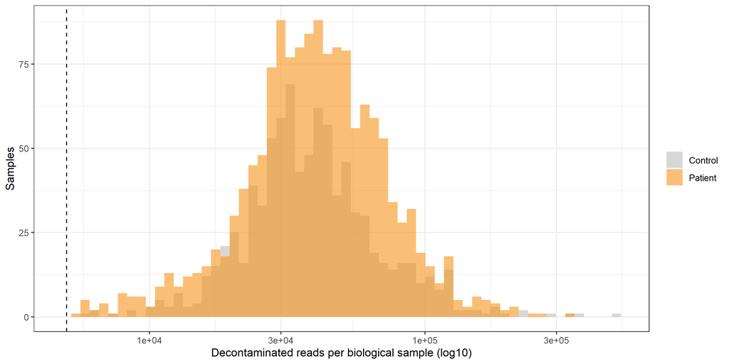

```r
depth <- data.frame(sample_data(ps_bio), check.names = FALSE)
depth$reads <- sample_sums(ps_bio)[depth$Sample_ID]
depth$retained_5000 <- depth$reads >= rarefaction_depth
write_table(depth, "rarefaction_inclusion")
save_plot(ggplot(depth, aes(reads, fill = status)) + geom_histogram(bins = 60, alpha = 0.6,
  position = "identity") + scale_x_log10() + scale_fill_manual(values = status_colors) +
  geom_vline(xintercept = rarefaction_depth, linetype = 2) +
  labs(x = "Decontaminated reads per biological sample (log10)", y = "Samples", fill = NULL), "depth", 10, 5)
```

```r
knitr::kable(depth |> dplyr::group_by(status, retained_5000) |>
  dplyr::summarise(samples = dplyr::n(), individuals = dplyr::n_distinct(individual), .groups = "drop"))
```

| status | retained_5000 | samples | individuals |
| --- | --- | --- | --- |
| Control | TRUE | 868 | 190 |
| Patient | TRUE | 1451 | 228 |

# 6 Alpha diversity at 5,000 reads

Boxplots display biological samples. Tests use the mean of each index per individual and region, avoiding duplicated evidence from two lesion locations. Control–patient comparisons use unpaired Wilcoxon tests. Perilesional–contralateral tests use patient-paired Wilcoxon tests. Control comparisons are unpaired. BH adjustment is applied across the planned contrasts within each index.

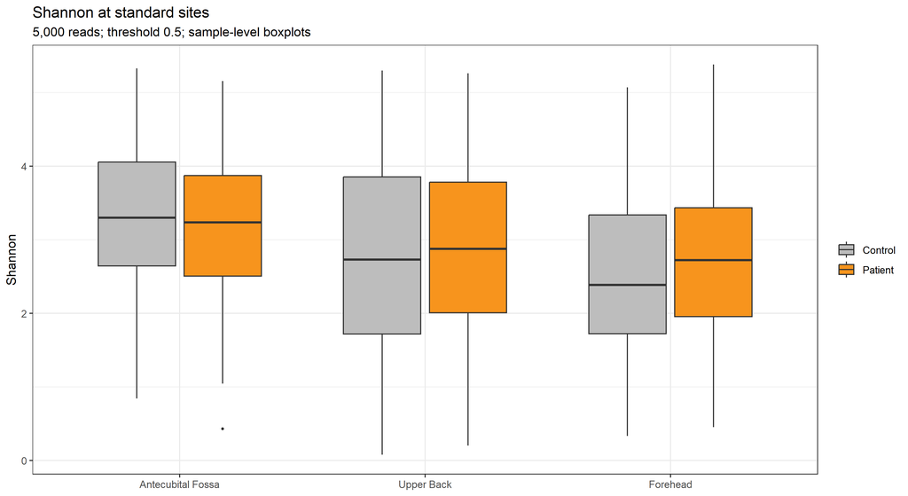

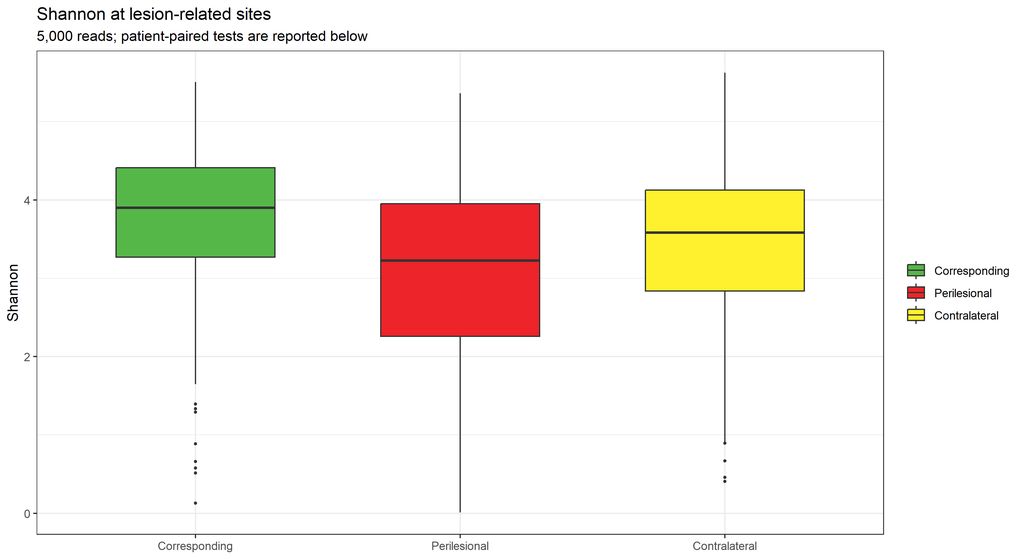

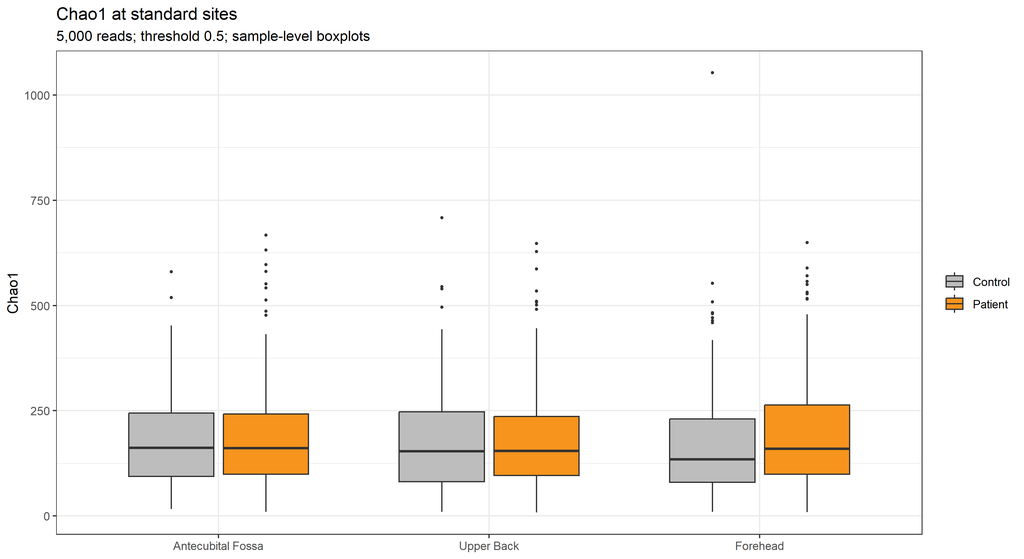

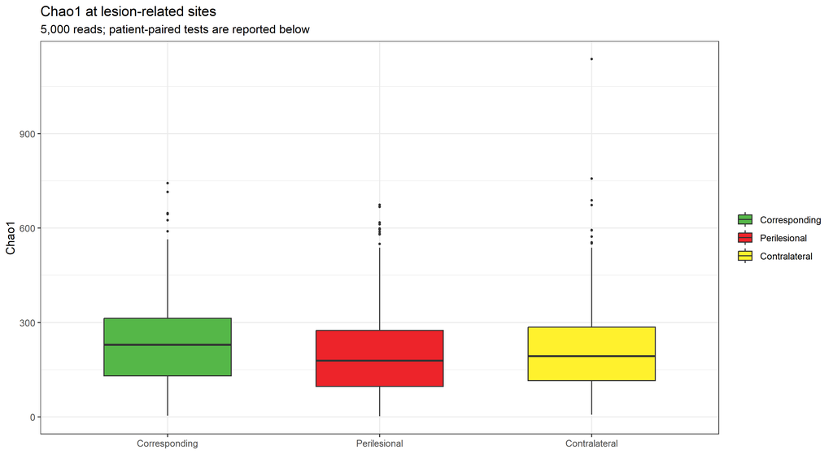

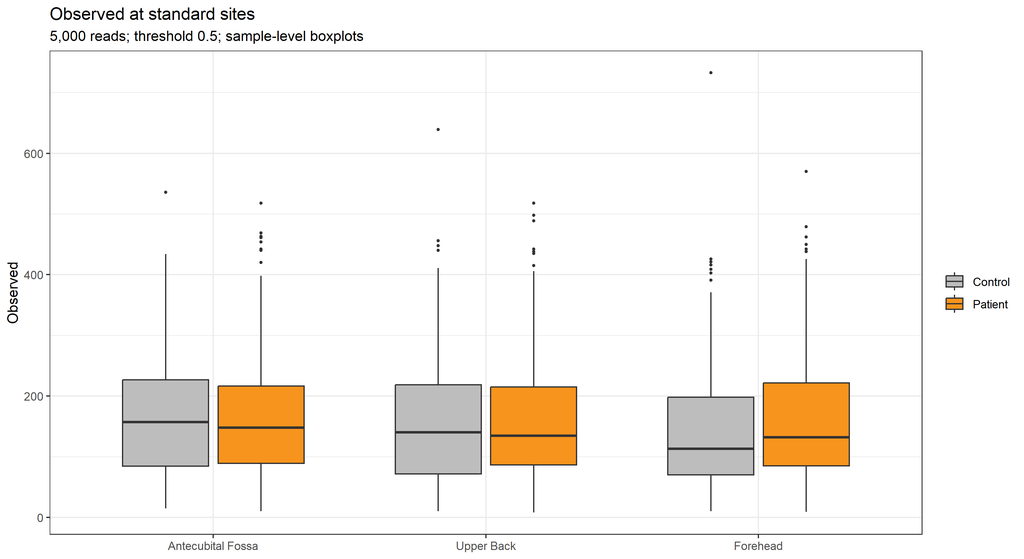

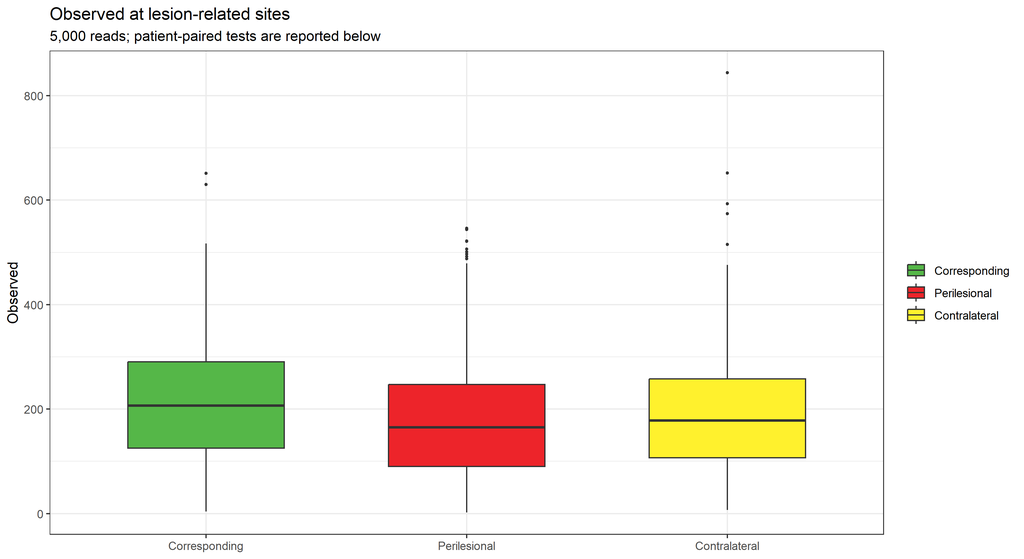

```r
set.seed(42)
rare_matrix <- vegan::rrarefy(t(get_counts(ps_bio)), sample = rarefaction_depth)
ps_rare <- ps_bio
otu_table(ps_rare) <- otu_table(t(rare_matrix), taxa_are_rows = TRUE)
ps_rare <- prune_taxa(taxa_sums(ps_rare) > 0, ps_rare)
if (any(sample_sums(ps_rare) != rarefaction_depth)) stop("Rarefaction depth verification failed.")
alpha <- estimate_richness(ps_rare, measures = c("Observed", "Shannon", "Chao1"))
alpha$Sample_ID <- rownames(alpha)
alpha <- dplyr::left_join(alpha, bio_meta, by = "Sample_ID")
write_table(alpha, "alpha_diversity")
alpha_subject <- alpha |> dplyr::group_by(individual, status, region) |>
  dplyr::summarise(dplyr::across(c(Observed, Shannon, Chao1), mean), .groups = "drop")
alpha_tests <- list()
for (metric in c("Shannon", "Chao1", "Observed")) {
  for (site_name in c("Antecubital Fossa", "Upper Back", "Forehead")) {
    dd <- alpha_subject[alpha_subject$region == site_name, ]
    a <- dd[[metric]][dd$status == "Control"]; b <- dd[[metric]][dd$status == "Patient"]
    alpha_tests[[length(alpha_tests) + 1]] <- data.frame(metric, comparison = paste(site_name, "Control vs Patient"),
      n1 = length(a), n2 = length(b), paired = FALSE, median1 = median(a), median2 = median(b),
      p = wilcox.test(a, b, exact = FALSE)$p.value)
  }
  for (pair in list(c("Corresponding", "Perilesional"), c("Corresponding", "Contralateral"),
                    c("Perilesional", "Contralateral"))) {
    dd <- alpha_subject[alpha_subject$region %in% pair, ]
    paired <- pair[1] == "Perilesional"
    if (paired) {
      wide <- dd |> dplyr::select(individual, region, dplyr::all_of(metric)) |>
        tidyr::pivot_wider(names_from = region, values_from = dplyr::all_of(metric))
      wide <- wide[complete.cases(wide), ]
      a <- wide[[pair[1]]]; b <- wide[[pair[2]]]
    } else {
      a <- dd[[metric]][dd$region == pair[1]]; b <- dd[[metric]][dd$region == pair[2]]
    }
    alpha_tests[[length(alpha_tests) + 1]] <- data.frame(metric, comparison = paste(pair, collapse = " vs "),
      n1 = length(a), n2 = length(b), paired, median1 = median(a), median2 = median(b),
      p = wilcox.test(a, b, paired = paired, exact = FALSE)$p.value)
  }
  standard <- alpha[alpha$panel == "Standard sites", ]
  standard$region <- factor(standard$region, levels = c("Antecubital Fossa", "Upper Back", "Forehead"))
  save_plot(ggplot(standard, aes(region, .data[[metric]], fill = status)) +
    geom_boxplot(width = 0.7, outlier.size = 0.8) + scale_fill_manual(values = status_colors) +
    labs(x = NULL, y = metric, fill = NULL, title = paste(metric, "at standard sites"),
         subtitle = "5,000 reads; threshold 0.5; sample-level boxplots"), paste0("alpha_", metric, "_standard"))
  lesion <- alpha[alpha$panel == "Lesion-related sites", ]
  lesion$region <- factor(lesion$region, levels = names(lesion_colors))
  save_plot(ggplot(lesion, aes(region, .data[[metric]], fill = region)) +
    geom_boxplot(width = 0.6, outlier.size = 0.8) + scale_fill_manual(values = lesion_colors) +
    labs(x = NULL, y = metric, fill = NULL, title = paste(metric, "at lesion-related sites"),
         subtitle = "5,000 reads; patient-paired tests are reported below"), paste0("alpha_", metric, "_lesion"))
}
```

```r
alpha_tests <- dplyr::bind_rows(alpha_tests) |> dplyr::group_by(metric) |>
  dplyr::mutate(q_BH = p.adjust(p, "BH")) |> dplyr::ungroup()
write_table(alpha_tests, "alpha_tests")
knitr::kable(alpha_tests, digits = 4)
```

| metric | comparison | n1 | n2 | paired | median1 | median2 | p | q_BH |
| --- | --- | --- | --- | --- | --- | --- | --- | --- |
| Shannon | Antecubital Fossa Control vs Patient | 175 | 207 | FALSE | 3.3015 | 3.2347 | 0.4429 | 0.4429 |
| Shannon | Upper Back Control vs Patient | 175 | 208 | FALSE | 2.7288 | 2.8748 | 0.4328 | 0.4429 |
| Shannon | Forehead Control vs Patient | 184 | 213 | FALSE | 2.3847 | 2.7137 | 0.0623 | 0.0934 |
| Shannon | Corresponding vs Perilesional | 181 | 220 | FALSE | 3.8442 | 3.2244 | 0.0000 | 0.0000 |
| Shannon | Corresponding vs Contralateral | 181 | 219 | FALSE | 3.8442 | 3.5297 | 0.0001 | 0.0001 |
| Shannon | Perilesional vs Contralateral | 215 | 215 | TRUE | 3.2275 | 3.5373 | 0.0000 | 0.0000 |
| Chao1 | Antecubital Fossa Control vs Patient | 175 | 207 | FALSE | 162.0000 | 161.0000 | 0.6756 | 0.8107 |
| Chao1 | Upper Back Control vs Patient | 175 | 208 | FALSE | 153.4400 | 154.0982 | 0.9038 | 0.9038 |
| Chao1 | Forehead Control vs Patient | 184 | 213 | FALSE | 134.3958 | 159.0000 | 0.0286 | 0.0429 |
| Chao1 | Corresponding vs Perilesional | 181 | 220 | FALSE | 222.3125 | 182.1999 | 0.0004 | 0.0024 |
| Chao1 | Corresponding vs Contralateral | 181 | 219 | FALSE | 222.3125 | 195.5682 | 0.0235 | 0.0429 |
| Chao1 | Perilesional vs Contralateral | 215 | 215 | TRUE | 183.8333 | 195.8304 | 0.0152 | 0.0429 |
| Observed | Antecubital Fossa Control vs Patient | 175 | 207 | FALSE | 157.0000 | 148.0000 | 0.8714 | 0.9771 |
| Observed | Upper Back Control vs Patient | 175 | 208 | FALSE | 140.0000 | 134.5000 | 0.9771 | 0.9771 |
| Observed | Forehead Control vs Patient | 184 | 213 | FALSE | 113.0000 | 132.0000 | 0.0355 | 0.0533 |
| Observed | Corresponding vs Perilesional | 181 | 220 | FALSE | 212.0000 | 164.0000 | 0.0000 | 0.0001 |
| Observed | Corresponding vs Contralateral | 181 | 219 | FALSE | 212.0000 | 177.0000 | 0.0084 | 0.0168 |
| Observed | Perilesional vs Contralateral | 215 | 215 | TRUE | 166.0000 | 180.0000 | 0.0011 | 0.0032 |

# 7 Beta diversity and PERMANOVA

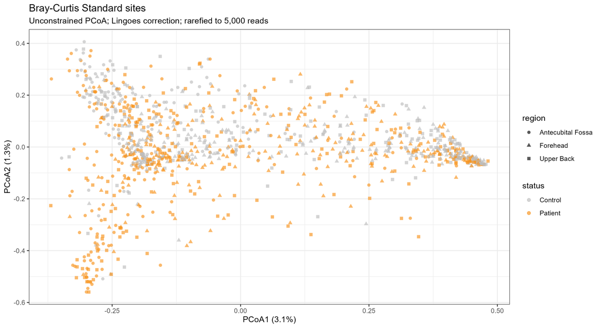

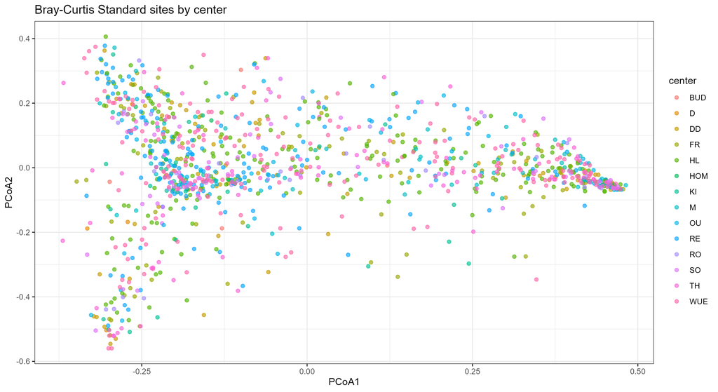

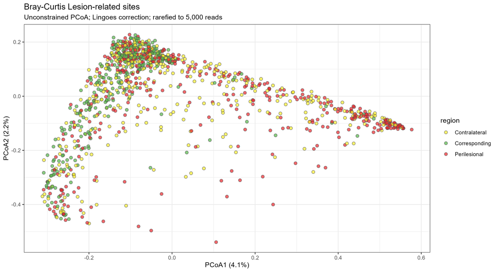

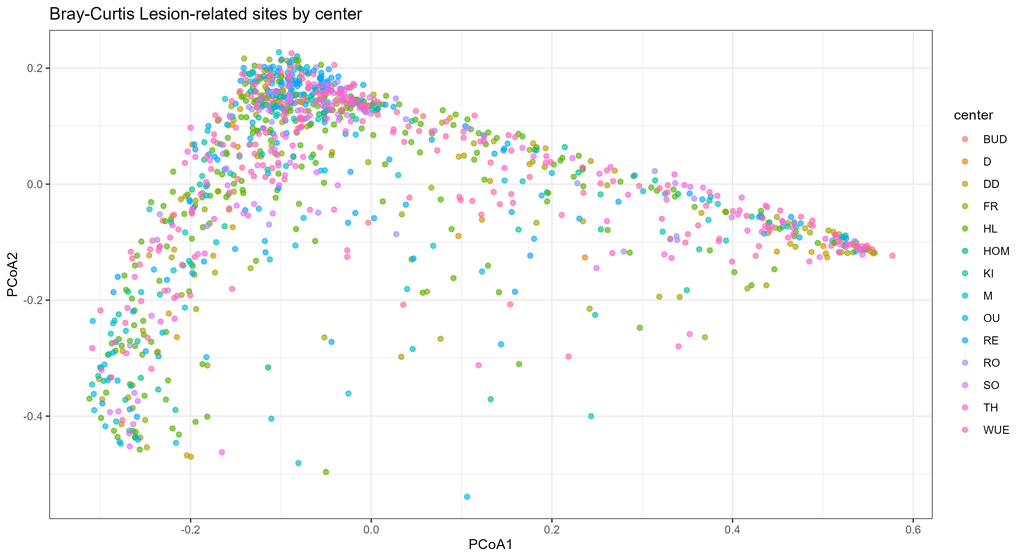

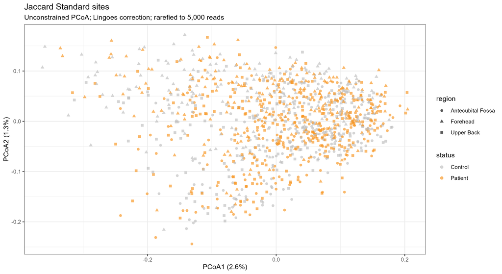

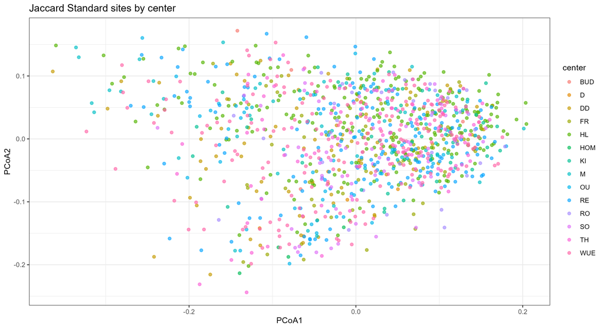

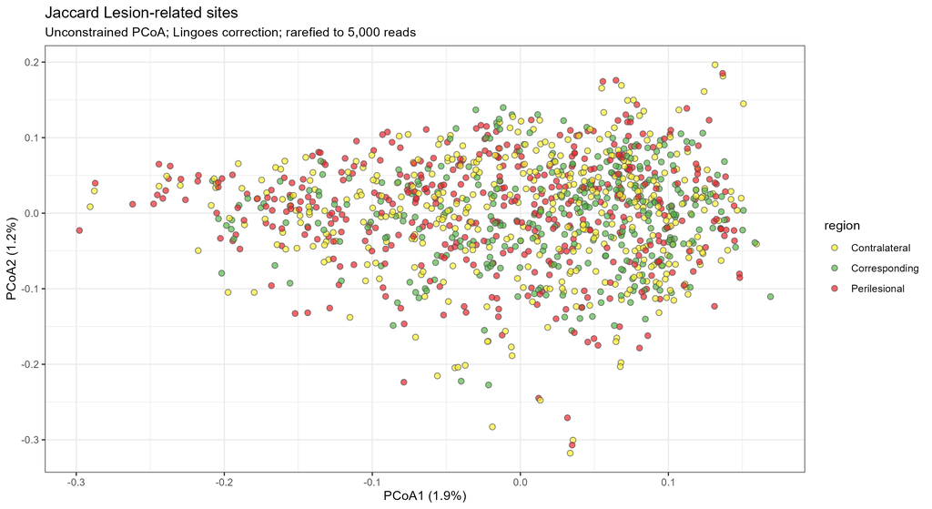

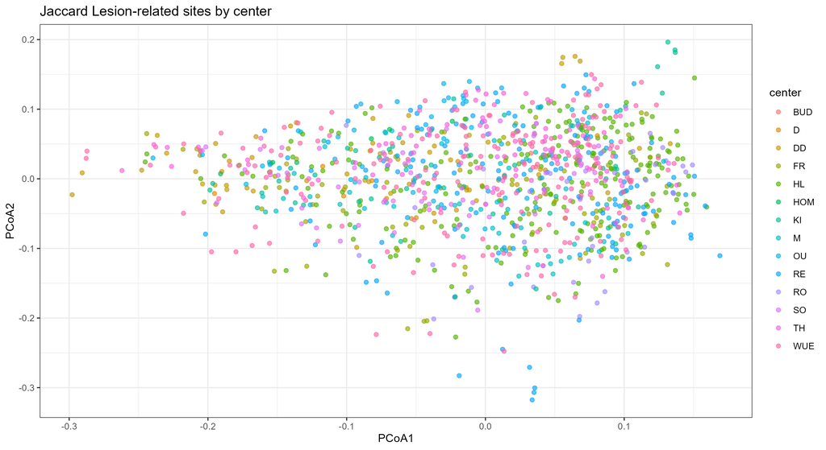

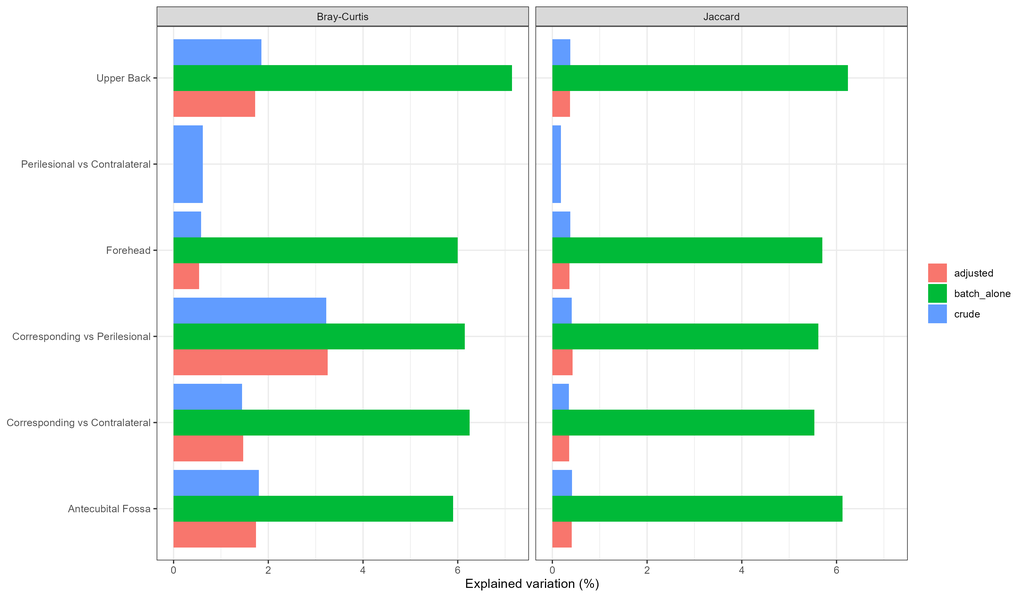

```r
rare_counts <- t(get_counts(ps_rare))
rare_meta <- bio_meta[match(rownames(rare_counts), bio_meta$Sample_ID), ]
beta_result_file <- file.path(out_dir, "13_PERMANOVA_and_dispersion.csv")
beta_images <- file.path(out_dir, c(
  "13_PCoA_Bray-Curtis_Standard_sites.png",
  "13_PCoA_Bray-Curtis_Standard_sites_center.png",
  "13_PCoA_Bray-Curtis_Lesion-related_sites.png",
  "13_PCoA_Bray-Curtis_Lesion-related_sites_center.png",
  "13_PCoA_Jaccard_Standard_sites.png",
  "13_PCoA_Jaccard_Standard_sites_center.png",
  "13_PCoA_Jaccard_Lesion-related_sites.png",
  "13_PCoA_Jaccard_Lesion-related_sites_center.png",
  "13_PERMANOVA_R2.png"
))
if (file.exists(beta_result_file) && all(file.exists(beta_images))) {
  beta_results <- utils::read.csv(beta_result_file, check.names = FALSE)
  knitr::include_graphics(beta_images)
} else {
beta_results <- list()
for (metric in c("Bray-Curtis", "Jaccard")) {
  for (panel_name in c("Standard sites", "Lesion-related sites")) {
    ii <- which(rare_meta$panel == panel_name)
    x <- rare_counts[ii, , drop = FALSE]; x <- x[, colSums(x) > 0, drop = FALSE]
    dd <- rare_meta[ii, ]
    dst <- vegan::vegdist(x, method = if (metric == "Bray-Curtis") "bray" else "jaccard",
                         binary = metric == "Jaccard")
    ord <- ape::pcoa(dst, correction = "lingoes")
    coords <- if (!is.null(ord$vectors.cor)) ord$vectors.cor[, 1:2] else ord$vectors[, 1:2]
    eig <- if ("Rel_corr_eig" %in% names(ord$values)) ord$values$Rel_corr_eig else ord$values$Relative_eig
    dd$PCoA1 <- coords[, 1]; dd$PCoA2 <- coords[, 2]
    write_table(dd, paste0("PCoA_", metric, "_", gsub(" ", "_", panel_name)))
    p <- ggplot(dd, aes(PCoA1, PCoA2)) +
      labs(x = sprintf("PCoA1 (%.1f%%)", eig[1] * 100), y = sprintf("PCoA2 (%.1f%%)", eig[2] * 100),
           title = paste(metric, panel_name), subtitle = "Unconstrained PCoA; Lingoes correction; rarefied to 5,000 reads")
    if (panel_name == "Standard sites") {
      p <- p + geom_point(aes(color = status, shape = region), alpha = 0.65, size = 1.7) +
        scale_color_manual(values = status_colors)
    } else {
      p <- p + geom_point(aes(fill = region), shape = 21, color = "grey30", alpha = 0.7, size = 2) +
        scale_fill_manual(values = lesion_colors)
    }
    save_plot(p, paste0("PCoA_", metric, "_", gsub(" ", "_", panel_name)))
    save_plot(ggplot(dd, aes(PCoA1, PCoA2, color = center)) + geom_point(alpha = 0.65, size = 1.6) +
      labs(title = paste(metric, panel_name, "by center"), x = "PCoA1", y = "PCoA2"),
      paste0("PCoA_", metric, "_", gsub(" ", "_", panel_name), "_center"))
  }
  for (comparison in c("Antecubital Fossa", "Upper Back", "Forehead", "Corresponding vs Perilesional",
                       "Corresponding vs Contralateral", "Perilesional vs Contralateral")) {
    paired <- comparison == "Perilesional vs Contralateral"
    if (!grepl(" vs ", comparison)) {
      dd <- rare_meta[rare_meta$region == comparison, ]
      dd <- dd[order(dd$Sample_ID), ]; dd <- dd[!duplicated(dd$individual), ]
      dd$group <- droplevels(dd$status)
    } else {
      regions <- strsplit(comparison, " vs ", fixed = TRUE)[[1]]
      dd <- rare_meta[rare_meta$region %in% regions, ]
      if (paired) {
        keys <- table(paste(dd$individual, dd$pair_number), dd$region)
        complete_keys <- rownames(keys)[rowSums(keys > 0) == 2]
        dd <- dd[paste(dd$individual, dd$pair_number) %in% complete_keys, ]
        dd <- dd[order(dd$Sample_ID), ]
        chosen <- dd[!duplicated(dd$individual), c("individual", "pair_number")]
        dd <- dd[paste(dd$individual, dd$pair_number) %in% paste(chosen$individual, chosen$pair_number), ]
      } else {
        dd <- dd[order(dd$Sample_ID), ]; dd <- dd[!duplicated(dd$individual), ]
      }
      dd$group <- factor(dd$region, levels = regions)
    }
    for (model in c("batch_alone", "crude", "adjusted")) {
      if (paired && model != "crude") next
      fields <- if (model == "adjusted") c("center", "sex", "group") else if (model == "batch_alone") "extraction_batch" else "group"
      d <- droplevels(dd[complete.cases(dd[, fields, drop = FALSE]), ])
      d$center <- factor(d$center); d$sex <- factor(d$sex); d$extraction_batch <- factor(d$extraction_batch)
      x <- rare_counts[d$Sample_ID, , drop = FALSE]; x <- x[, colSums(x) > 0, drop = FALSE]
      dst <- vegan::vegdist(x, method = if (metric == "Bray-Curtis") "bray" else "jaccard", binary = metric == "Jaccard")
      rhs <- if (model == "adjusted") "center + sex + group" else if (model == "batch_alone") "extraction_batch" else "group"
      set.seed(42)
      fit <- vegan::adonis2(as.formula(paste("dst ~", rhs)), data = d, permutations = 999,
        by = "margin", strata = if (paired) d$individual else NULL)
      target <- if (model == "batch_alone") "extraction_batch" else "group"
      target_sizes <- table(d[[target]])
      if (length(target_sizes) < 2 || any(target_sizes < 2)) {
        dispersion_p <- NA_real_
      } else {
        dispers <- vegan::betadisper(dst, d[[target]], bias.adjust = FALSE, add = "lingoes")
        set.seed(42)
        dispersion_p <- vegan::permutest(dispers, permutations = 999)$tab[1, "Pr(>F)"]
      }
      beta_results[[length(beta_results) + 1]] <- data.frame(metric, comparison, model,
        samples = nrow(d), individuals = length(unique(d$individual)), formula = rhs,
        paired, R2 = fit[target, "R2"], F = fit[target, "F"], p = fit[target, "Pr(>F)"], dispersion_p)
    }
  }
}
beta_results <- dplyr::bind_rows(beta_results) |> dplyr::group_by(metric, model) |>
  dplyr::mutate(q_BH = p.adjust(p, "BH")) |> dplyr::ungroup()
write_table(beta_results, "PERMANOVA_and_dispersion")
knitr::kable(beta_results, digits = 4)
save_plot(ggplot(beta_results, aes(comparison, R2 * 100, fill = model)) + geom_col(position = "dodge") +
  facet_wrap(~metric) + coord_flip() + labs(x = NULL, y = "Explained variation (%)", fill = NULL), "PERMANOVA_R2", 12, 7)
}
```

```r
knitr::kable(beta_results, digits = 4)
```

| metric | comparison | model | samples | individuals | formula | paired | R2 | F | p | dispersion_p | q_BH |
| --- | --- | --- | --- | --- | --- | --- | --- | --- | --- | --- | --- |
| Bray-Curtis | Antecubital Fossa | batch_alone | 382 | 382 | extraction_batch | FALSE | 0.0590 | 1.2653 | 0.001 | NA | 0.0010 |
| Bray-Curtis | Antecubital Fossa | crude | 382 | 382 | group | FALSE | 0.0180 | 6.9753 | 0.001 | 0.711 | 0.0012 |
| Bray-Curtis | Antecubital Fossa | adjusted | 382 | 382 | center + sex + group | FALSE | 0.0174 | 6.9017 | 0.001 | 0.711 | 0.0013 |
| Bray-Curtis | Upper Back | batch_alone | 383 | 383 | extraction_batch | FALSE | 0.0715 | 1.5562 | 0.001 | NA | 0.0010 |
| Bray-Curtis | Upper Back | crude | 383 | 383 | group | FALSE | 0.0185 | 7.1896 | 0.001 | 0.007 | 0.0012 |
| Bray-Curtis | Upper Back | adjusted | 383 | 383 | center + sex + group | FALSE | 0.0172 | 7.1823 | 0.001 | 0.007 | 0.0013 |
| Bray-Curtis | Forehead | batch_alone | 397 | 397 | extraction_batch | FALSE | 0.0600 | 1.3398 | 0.001 | NA | 0.0010 |
| Bray-Curtis | Forehead | crude | 397 | 397 | group | FALSE | 0.0058 | 2.3000 | 0.006 | 0.146 | 0.0060 |
| Bray-Curtis | Forehead | adjusted | 397 | 397 | center + sex + group | FALSE | 0.0054 | 2.2221 | 0.009 | 0.146 | 0.0090 |
| Bray-Curtis | Corresponding vs Perilesional | batch_alone | 401 | 401 | extraction_batch | FALSE | 0.0615 | 1.4752 | 0.001 | 0.002 | 0.0010 |
| Bray-Curtis | Corresponding vs Perilesional | crude | 401 | 401 | group | FALSE | 0.0322 | 13.2833 | 0.001 | 0.434 | 0.0012 |
| Bray-Curtis | Corresponding vs Perilesional | adjusted | 401 | 401 | center + sex + group | FALSE | 0.0326 | 13.8708 | 0.001 | 0.434 | 0.0013 |
| Bray-Curtis | Corresponding vs Contralateral | batch_alone | 400 | 400 | extraction_batch | FALSE | 0.0625 | 1.4977 | 0.001 | 0.021 | 0.0010 |
| Bray-Curtis | Corresponding vs Contralateral | crude | 400 | 400 | group | FALSE | 0.0145 | 5.8401 | 0.001 | 0.638 | 0.0012 |
| Bray-Curtis | Corresponding vs Contralateral | adjusted | 400 | 400 | center + sex + group | FALSE | 0.0147 | 6.1040 | 0.001 | 0.638 | 0.0013 |
| Bray-Curtis | Perilesional vs Contralateral | crude | 424 | 212 | group | TRUE | 0.0062 | 2.6202 | 0.001 | 0.518 | 0.0012 |
| Jaccard | Antecubital Fossa | batch_alone | 382 | 382 | extraction_batch | FALSE | 0.0612 | 1.3154 | 0.001 | NA | 0.0010 |
| Jaccard | Antecubital Fossa | crude | 382 | 382 | group | FALSE | 0.0041 | 1.5771 | 0.001 | 0.679 | 0.0010 |
| Jaccard | Antecubital Fossa | adjusted | 382 | 382 | center + sex + group | FALSE | 0.0041 | 1.5771 | 0.001 | 0.679 | 0.0010 |
| Jaccard | Upper Back | batch_alone | 383 | 383 | extraction_batch | FALSE | 0.0624 | 1.3455 | 0.001 | NA | 0.0010 |
| Jaccard | Upper Back | crude | 383 | 383 | group | FALSE | 0.0038 | 1.4422 | 0.001 | 0.329 | 0.0010 |
| Jaccard | Upper Back | adjusted | 383 | 383 | center + sex + group | FALSE | 0.0037 | 1.4518 | 0.001 | 0.329 | 0.0010 |
| Jaccard | Forehead | batch_alone | 397 | 397 | extraction_batch | FALSE | 0.0570 | 1.2695 | 0.001 | NA | 0.0010 |
| Jaccard | Forehead | crude | 397 | 397 | group | FALSE | 0.0038 | 1.5039 | 0.001 | 0.082 | 0.0010 |
| Jaccard | Forehead | adjusted | 397 | 397 | center + sex + group | FALSE | 0.0036 | 1.4637 | 0.001 | 0.082 | 0.0010 |
| Jaccard | Corresponding vs Perilesional | batch_alone | 401 | 401 | extraction_batch | FALSE | 0.0562 | 1.3403 | 0.001 | 0.001 | 0.0010 |
| Jaccard | Corresponding vs Perilesional | crude | 401 | 401 | group | FALSE | 0.0041 | 1.6350 | 0.001 | 0.394 | 0.0010 |
| Jaccard | Corresponding vs Perilesional | adjusted | 401 | 401 | center + sex + group | FALSE | 0.0043 | 1.7301 | 0.001 | 0.394 | 0.0010 |
| Jaccard | Corresponding vs Contralateral | batch_alone | 400 | 400 | extraction_batch | FALSE | 0.0553 | 1.3159 | 0.001 | 0.001 | 0.0010 |
| Jaccard | Corresponding vs Contralateral | crude | 400 | 400 | group | FALSE | 0.0035 | 1.3961 | 0.001 | 0.678 | 0.0010 |
| Jaccard | Corresponding vs Contralateral | adjusted | 400 | 400 | center + sex + group | FALSE | 0.0035 | 1.4325 | 0.001 | 0.678 | 0.0010 |
| Jaccard | Perilesional vs Contralateral | crude | 424 | 212 | group | TRUE | 0.0018 | 0.7686 | 0.001 | 0.218 | 0.0010 |

# 8 Taxonomic composition using unrarefied counts

The genus bars use the project’s existing `functions.R::taxa_plot()` implementation and its phylum-dependent colors. Relative abundances are averaged with equal sample weight within each displayed group. Samples below 5,000 reads remain eligible here if they have positive decontaminated depth. No additional taxa are removed for plotting; non-displayed genera remain in the denominator and are represented as Other.

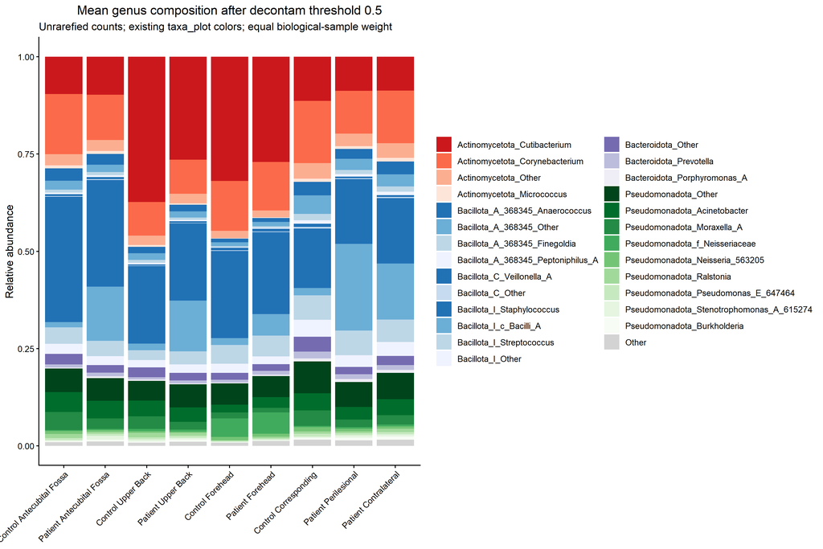

```r
# Evaluate the existing plotting function only; preserve its implementation and palettes.
helper_expressions <- parse(file.path(project_dir, "functions.R"))
for (expr in helper_expressions) {
  if (is.call(expr) && as.character(expr[[1]]) %in% c("<-", "=") &&
      identical(as.character(expr[[2]]), "taxa_plot")) eval(expr)
}
counts <- get_counts(ps_bio)
rel <- sweep(counts, 2, colSums(counts), "/")
tax <- data.frame(tax_table(ps_bio), check.names = FALSE)
md <- data.frame(sample_data(ps_bio), check.names = FALSE)
md$plot_group <- ifelse(md$panel == "Standard sites", paste(md$status, md$region),
                       paste(md$status, md$region))
group_levels <- c("Control Antecubital Fossa", "Patient Antecubital Fossa", "Control Upper Back",
  "Patient Upper Back", "Control Forehead", "Patient Forehead", "Control Corresponding",
  "Patient Perilesional", "Patient Contralateral")
md$plot_group <- factor(md$plot_group, levels = group_levels)
genus_key <- paste(tax$Phylum, tax$Genus, sep = "|")
genus_rel <- rowsum(rel, genus_key, reorder = FALSE)
genus_tax <- tax[match(rownames(genus_rel), genus_key), , drop = FALSE]
top_genus_ids <- rownames(genus_rel)[order(rowMeans(genus_rel), decreasing = TRUE)[seq_len(min(20, nrow(genus_rel)))]]
genus_mean <- vapply(group_levels, function(g) rowMeans(genus_rel[, md$plot_group == g, drop = FALSE]), numeric(nrow(genus_rel)))
rownames(genus_mean) <- rownames(genus_rel)
genus_long <- data.frame(genus_mean, check.names = FALSE) |>
  tibble::rownames_to_column("OTU") |> tidyr::pivot_longer(-OTU, names_to = "plot_group", values_to = "Abundance")
genus_long$Phylum <- genus_tax$Phylum[match(genus_long$OTU, rownames(genus_rel))]
genus_long$Genus <- genus_tax$Genus[match(genus_long$OTU, rownames(genus_rel))]
genus_long$plot_group <- factor(genus_long$plot_group, levels = group_levels)
genus_long <- data.frame(genus_long, check.names = FALSE)
genus_plot <- taxa_plot(genus_long, taxa = "Genus", tax_otu = top_genus_ids, x_axis = "plot_group")
save_plot(genus_plot$plot + labs(title = "Mean genus composition after decontam threshold 0.5",
  subtitle = "Unrarefied counts; existing taxa_plot colors; equal biological-sample weight", x = NULL), "genus_composition", 13, 8)
```

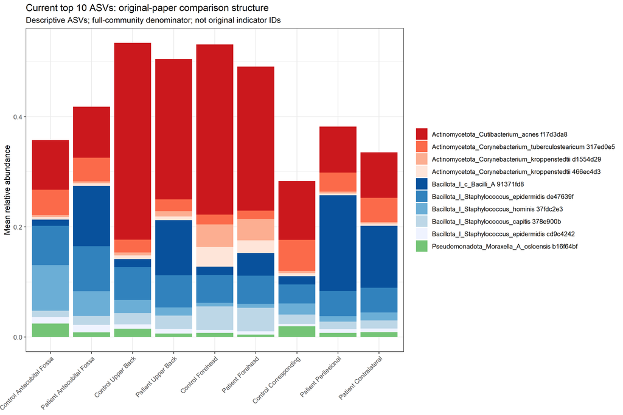

```r
write_table(genus_long, "genus_group_abundance")
write_table(data.frame(label = levels(genus_plot$data$df$Genus), color = genus_plot$color), "taxa_color_mapping")

# Current top ASVs are descriptive, not reidentified original indicator ASVs.
top_asvs <- names(sort(rowMeans(rel), decreasing = TRUE))[seq_len(min(10, nrow(rel)))]
asv_mean <- vapply(group_levels, function(g) rowMeans(rel[top_asvs, md$plot_group == g, drop = FALSE]), numeric(length(top_asvs)))
rownames(asv_mean) <- top_asvs
asv_long <- data.frame(asv_mean, check.names = FALSE) |> tibble::rownames_to_column("feature_id") |>
  tidyr::pivot_longer(-feature_id, names_to = "plot_group", values_to = "Abundance")
asv_long$Phylum <- tax$Phylum[match(asv_long$feature_id, rownames(tax))]
asv_long$Species <- tax$Species[match(asv_long$feature_id, rownames(tax))]
asv_long$OTU <- asv_long$feature_id
asv_long$ASV_label <- paste(asv_long$Species, substr(asv_long$feature_id, 1, 8))
asv_long$plot_group <- factor(asv_long$plot_group, levels = group_levels)
asv_long <- data.frame(asv_long, check.names = FALSE)
asv_palette <- taxa_plot(asv_long, taxa = "ASV_label", tax_otu = top_asvs, x_axis = "plot_group")
asv_data <- asv_palette$data$df
save_plot(ggplot(asv_data, aes(plot_group, Abundance, fill = ASV_label)) + geom_col() +
  scale_fill_manual(values = asv_palette$color) + labs(x = NULL, y = "Mean relative abundance", fill = NULL,
  title = "Current top 10 ASVs: original-paper comparison structure",
  subtitle = "Descriptive ASVs; full-community denominator; not original indicator IDs") +
  theme(axis.text.x = element_text(angle = 45, hjust = 1)), "top_ASV_composition", 14, 8)
```

```r
write_table(asv_long, "top_ASV_group_abundance")
```

# 9 BPDAI and S. aureus abundance

S. aureus is identified from the current taxonomy by an exact species-name match and its ASVs are summed per sample. This is a species-aggregate reanalysis, not a claim of sequence identity with the original paper’s ASV_2. 16S species assignments are used as provided and do not resolve strain identity.

The primary correlation uses one mean abundance per patient and region, so patients with two lesion sites are counted once. Sample-level Spearman estimates are included as a descriptive comparison only. BPDAI-missing patients are listed in the matching table.

```r
species_clean <- gsub("_", " ", tax$Species)
aureus <- rownames(tax)[species_clean == "Staphylococcus aureus"]
write_table(data.frame(feature_id = aureus, tax[aureus, , drop = FALSE], row.names = NULL), "S_aureus_ASVs")
if (!length(aureus)) {
  cat("No exact Staphylococcus aureus species assignments are present; the requested species correlation cannot be estimated.\n")
} else {
  sa <- md
  sa$relative_abundance <- colSums(rel[aureus, , drop = FALSE])
  sa <- sa[sa$status == "Patient" & sa$region %in% c("Perilesional", "Contralateral") & !is.na(sa$BPDAI), ]
  sa_subject <- sa |> dplyr::group_by(individual, region, BPDAI) |>
    dplyr::summarise(relative_abundance = mean(relative_abundance), samples = dplyr::n(), .groups = "drop")
  corr <- list()
  for (unit in c("Patient mean", "Biological sample (descriptive)")) {
    z <- if (unit == "Patient mean") sa_subject else sa
    for (r in c("Perilesional", "Contralateral")) {
      dd <- z[z$region == r, ]
      ct <- cor.test(dd$BPDAI, dd$relative_abundance, method = "spearman", exact = FALSE)
      corr[[length(corr) + 1]] <- data.frame(unit, region = r, n = nrow(dd),
        individuals = length(unique(dd$individual)), rho = unname(ct$estimate), p = ct$p.value)
    }
  }
  corr <- dplyr::bind_rows(corr) |> dplyr::group_by(unit) |>
    dplyr::mutate(q_BH = p.adjust(p, "BH")) |> dplyr::ungroup()
  labels <- corr[corr$unit == "Patient mean", ]
  labels$label <- sprintf("n = %d patients\nrho = %.3f; BH q = %.3g", labels$individuals, labels$rho, labels$q_BH)
  save_plot(ggplot(sa_subject, aes(BPDAI, relative_abundance * 100)) + geom_point(alpha = 0.6, size = 1.8) +
    facet_wrap(~region) + geom_text(data = labels, aes(x = Inf, y = Inf, label = label), inherit.aes = FALSE,
      hjust = 1.1, vjust = 1.2, size = 3.5, color = "blue") +
    labs(x = "BPDAI activity score (Active sum)", y = "Mean S. aureus relative abundance (%)",
      title = "S. aureus abundance and BP disease activity", subtitle = "One point per patient per region; unrarefied decontaminated counts"),
    "BPDAI_S_aureus", 11, 5)
  write_table(sa, "BPDAI_sample_abundance")
  write_table(sa_subject, "BPDAI_patient_mean_abundance")
  write_table(corr, "BPDAI_correlations")
  knitr::kable(corr, digits = 4)
}
```

```
## No exact Staphylococcus aureus species assignments are present; the requested species correlation cannot be estimated.
```

# 10 Final analysis objects and reproducibility

```r
saveRDS(list(unrarefied_decontam_0.5 = ps_bio, rarefied_5000 = ps_rare),
        file.path(out_dir, "13_Test9_decontam_0.5_analysis_phyloseq.rds"))
final_counts <- data.frame(dataset = c("Taxa/BPDAI: unrarefied", "Alpha/beta: rarefied 5000"),
  samples = c(nsamples(ps_bio), nsamples(ps_rare)),
  individuals = c(length(unique(sample_data(ps_bio)$individual)), length(unique(sample_data(ps_rare)$individual))),
  ASVs = c(ntaxa(ps_bio), ntaxa(ps_rare)))
write_table(final_counts, "final_counts")
knitr::kable(final_counts)
```

| dataset | samples | individuals | ASVs |
| --- | --- | --- | --- |
| Taxa/BPDAI: unrarefied | 2319 | 418 | 76260 |
| Alpha/beta: rarefied 5000 | 2319 | 418 | 62040 |

To rerun from the R project, open this Rmd and Knit, or run:

```r
rmarkdown::render("13_Test9_original_paper_replication.Rmd",
  output_dir = "Results/Test9/13_Test9_original_paper_replication",
  envir = new.env(parent = globalenv()))
```